# Laboratorio n° 5

Oscar Centeno Mora

Tomorrow never dies

# Intervención m=1

## Descripción de los datos

```r
url <- "https://www.openintro.org/stat/data/arbuthnot.csv"
abhutondot <- read.csv(url, header=TRUE)
nrow(abhutondot)
```

```
## [1] 82
```

```r
head(abhutondot)
```

```
##   year boys girls
## 1 1629 5218  4683
## 2 1630 4858  4457
## 3 1631 4422  4102
## 4 1632 4994  4590
## 5 1633 5158  4839
## 6 1634 5035  4820
```

```r
abhutondot_rs <- melt(abhutondot, id = c("year"))
head(abhutondot_rs)
```

```
##   year variable value
## 1 1629     boys  5218
## 2 1630     boys  4858
## 3 1631     boys  4422
## 4 1632     boys  4994
## 5 1633     boys  5158
## 6 1634     boys  5035
```

```r
tail(abhutondot_rs)
```

```
##     year variable value
## 159 1705    girls  7779
## 160 1706    girls  7417
## 161 1707    girls  7687
## 162 1708    girls  7623
## 163 1709    girls  7380
## 164 1710    girls  7288
```

## Definiendo la serie como una TS

```r
excess_frac <- (abhutondot$boys - abhutondot$girls)/abhutondot$girls
excess_ts <- ts(excess_frac, frequency = 1, start = abhutondot$year[1])
```

## Algunas estadísticas descriptivas

```r
basicStats(excess_frac)
```

```
##             excess_frac
## nobs          82.000000
## NAs            0.000000
## Minimum        0.010673
## Maximum        0.156075
## 1. Quartile    0.048469
## 3. Quartile    0.087510
## Mean           0.070748
## Median         0.064704
## Sum            5.801343
## SE Mean        0.003451
## LCL Mean       0.063881
## UCL Mean       0.077615
## Variance       0.000977
## Stdev          0.031254
## Skewness       0.680042
## Kurtosis       0.073620
```

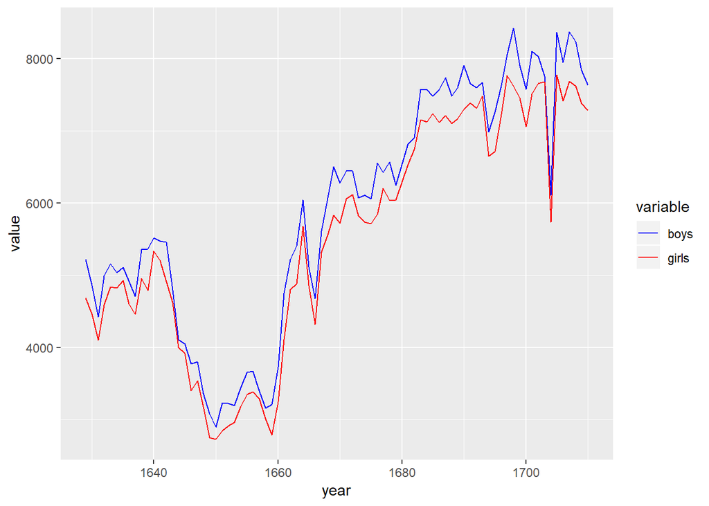

```r
#Gráfica de la serie

ggplot(data = abhutondot_rs, aes(x = year)) + geom_line(aes(y = value, colour = variable)) +
  scale_colour_manual(values = c("blue", "red"))
```

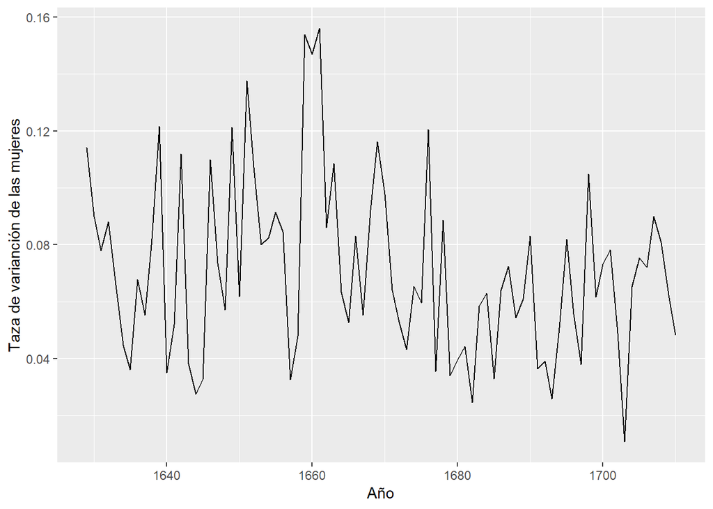

```r
#Gráfica de la varianción de genero según mujeres

autoplot(excess_ts) +  ylab("Taza de varianción de las mujeres") + xlab("Año")
```

## Cambios estructurales

```r
#Normalmente, podemos observar un cambio o identificar la intervención mediante conocimiento.
#Tambien es posible mediante

(break_point <- breakpoints(excess_ts ~ 1))
```

```
##
##   Optimal 2-segment partition:
##
## Call:
## breakpoints.formula(formula = excess_ts ~ 1)
##
## Breakpoints at observation number:
## 42
##
## Corresponding to breakdates:
## 1670
```

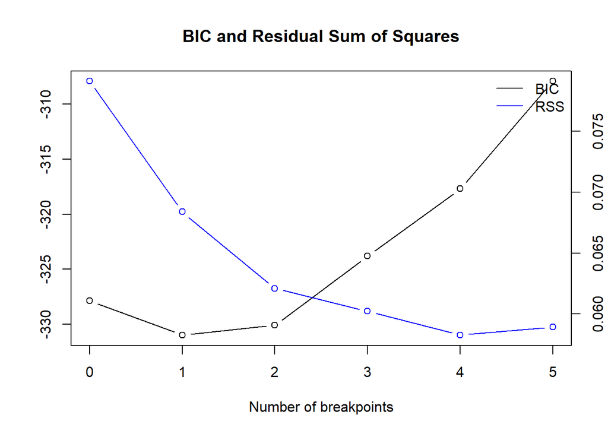

```r
plot(break_point)
```

```r
summary(break_point)
```

```
##
##   Optimal (m+1)-segment partition:
##
## Call:
## breakpoints.formula(formula = excess_ts ~ 1)
##
## Breakpoints at observation number:
##
## m = 1         42
## m = 2   20    42
## m = 3   20 35 48
## m = 4   20 35    50 66
## m = 5   17 30 42 56 69
##
## Corresponding to breakdates:
##
## m = 1             1670
## m = 2   1648      1670
## m = 3   1648 1663 1676
## m = 4   1648 1663      1678 1694
## m = 5   1645 1658 1670 1684 1697
##
## Fit:
##
## m   0          1          2          3          4          5
## RSS    0.07912    0.06840    0.06210    0.06022    0.05826    0.05894
## BIC -327.84807 -330.97945 -330.08081 -323.78985 -317.68933 -307.92410
```

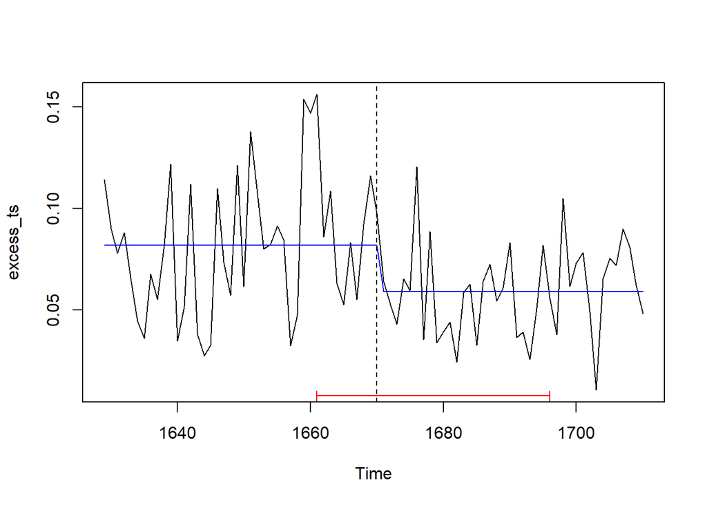

```r
#El valor mínimo de BIC se alcanza cuando m = 1, por lo que solo se determina
#un punto de ruptura correspondiente al año 1670. Tracemos la serie temporal
#original contra su ruptura estructural y su intervalo de confianza.


plot(excess_ts)
lines(fitted(break_point, breaks = 1), col = 4)
lines(confint(break_point, breaks = 1))
```

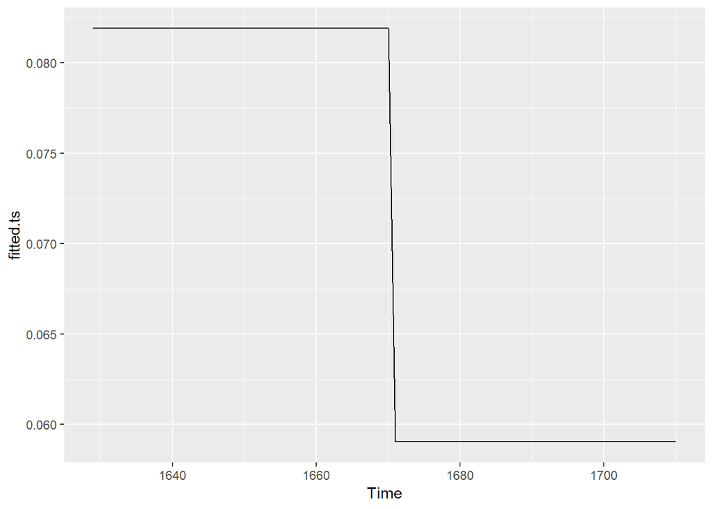

```r
fitted.ts <- fitted(break_point, breaks = 1)
autoplot(fitted.ts)
```

```r
fitted(break_point)[1] ;  fitted(break_point)[42] ;  fitted(break_point)[43] ; fitted(break_point)[82]
```

```
## [1] 0.08190905
```

```
## [1] 0.08190905
```

```
## [1] 0.05902908
```

```
## [1] 0.05902908
```

```r
#Nótese que el valor resulta como la constante donde la media es estimada, a partir de la observación 43
#vemos un cambio en el nivel de la serie.
```

## Estimación de 6 modelos ARIMA

Vamos a estimar los siguientes 6 modelos

1. non seasonal (1,1,1), as determined by auto.arima() within forecast package
2. seasonal (1,0,0)(0,0,1)[10]
3. seasonal (1,0,0)(1,0,0)[10]
4. seasonal (0,0,0)(0,0,1)[10] with level shift regressor as intervention variable
5. seasonal (1,0,0)(0,0,1)[10] with level shift regressor as intervention variable
6. non seasonal (1,0,0) with level shift regressor as intervention variable

```r
###################################
#  ARIMA 1. non seasonal (1,1,1)  #
###################################

(model_1 <- auto.arima(excess_ts, stepwise = FALSE, trace = TRUE))
```

```
##
##  ARIMA(0,1,0)                    : -301.4365
##  ARIMA(0,1,0) with drift         : -299.3722
##  ARIMA(0,1,1)                    : -328.9381
##  ARIMA(0,1,1) with drift         : -326.9276
##  ARIMA(0,1,2)                    : -329.4061
##  ARIMA(0,1,2) with drift         : Inf
##  ARIMA(0,1,3)                    : -327.2841
##  ARIMA(0,1,3) with drift         : Inf
##  ARIMA(0,1,4)                    : -325.7604
##  ARIMA(0,1,4) with drift         : Inf
##  ARIMA(0,1,5)                    : -323.4805
##  ARIMA(0,1,5) with drift         : Inf
##  ARIMA(1,1,0)                    : -312.8106
##  ARIMA(1,1,0) with drift         : -310.7155
##  ARIMA(1,1,1)                    : -329.5727
##  ARIMA(1,1,1) with drift         : Inf
##  ARIMA(1,1,2)                    : -327.3821
##  ARIMA(1,1,2) with drift         : Inf
##  ARIMA(1,1,3)                    : -325.1085
##  ARIMA(1,1,3) with drift         : Inf
##  ARIMA(1,1,4)                    : -323.446
##  ARIMA(1,1,4) with drift         : Inf
##  ARIMA(2,1,0)                    : -317.1234
##  ARIMA(2,1,0) with drift         : -314.9816
##  ARIMA(2,1,1)                    : -327.3795
##  ARIMA(2,1,1) with drift         : Inf
##  ARIMA(2,1,2)                    : -325.0859
##  ARIMA(2,1,2) with drift         : Inf
##  ARIMA(2,1,3)                    : -322.9714
##  ARIMA(2,1,3) with drift         : Inf
##  ARIMA(3,1,0)                    : -315.9114
##  ARIMA(3,1,0) with drift         : -313.7128
##  ARIMA(3,1,1)                    : -325.1497
##  ARIMA(3,1,1) with drift         : Inf
##  ARIMA(3,1,2)                    : -323.1363
##  ARIMA(3,1,2) with drift         : Inf
##  ARIMA(4,1,0)                    : -315.3018
##  ARIMA(4,1,0) with drift         : -313.0426
##  ARIMA(4,1,1)                    : -324.2463
##  ARIMA(4,1,1) with drift         : -322.0252
##  ARIMA(5,1,0)                    : -315.1075
##  ARIMA(5,1,0) with drift         : -312.7776
##
##
##
##  Best model: ARIMA(1,1,1)
```

```
## Series: excess_ts
## ARIMA(1,1,1)
##
## Coefficients:
##          ar1      ma1
##       0.2224  -0.9258
## s.e.  0.1318   0.0683
##
## sigma^2 estimated as 0.0009316:  log likelihood=167.94
## AIC=-329.88   AICc=-329.57   BIC=-322.7
```

```r
summary(model_1)
```

```
## Series: excess_ts
## ARIMA(1,1,1)
##
## Coefficients:
##          ar1      ma1
##       0.2224  -0.9258
## s.e.  0.1318   0.0683
##
## sigma^2 estimated as 0.0009316:  log likelihood=167.94
## AIC=-329.88   AICc=-329.57   BIC=-322.7
##
## Training set error measures:
##                        ME       RMSE        MAE       MPE     MAPE
## Training set -0.002931698 0.02995934 0.02405062 -27.05674 46.53832
##                   MASE        ACF1
## Training set 0.8292635 -0.01005689
```

```r
#######################################
#  ARIMA 2.  seasonal (1,0,0)(0,0,1)  #
#######################################

model_2 <- Arima(excess_ts, order = c(1,0,0), seasonal = list(order = c(0,0,1), period = 10), include.mean = TRUE)
summary(model_2)
```

```
## Series: excess_ts
## ARIMA(1,0,0)(0,0,1)[10] with non-zero mean
##
## Coefficients:
##          ar1    sma1    mean
##       0.2373  0.3441  0.0708
## s.e.  0.1104  0.1111  0.0053
##
## sigma^2 estimated as 0.0008129:  log likelihood=176.23
## AIC=-344.46   AICc=-343.94   BIC=-334.83
##
## Training set error measures:
##                         ME       RMSE        MAE       MPE     MAPE
## Training set -0.0002212383 0.02798445 0.02274858 -21.47547 42.96717
##                   MASE         ACF1
## Training set 0.7843692 -0.004420048
```

```r
#######################################
#  ARIMA 3. seasonal (1,0,0)(1,0,0)   #
#######################################

model_3 <- Arima(excess_ts, order = c(1,0,0), seasonal = list(order = c(1,0,0), period = 10), include.mean = TRUE)
summary(model_3)
```

```
## Series: excess_ts
## ARIMA(1,0,0)(1,0,0)[10] with non-zero mean
##
## Coefficients:
##          ar1    sar1    mean
##       0.2637  0.3185  0.0705
## s.e.  0.1069  0.1028  0.0058
##
## sigma^2 estimated as 0.0008173:  log likelihood=176.1
## AIC=-344.19   AICc=-343.67   BIC=-334.56
##
## Training set error measures:
##                         ME       RMSE        MAE       MPE     MAPE
## Training set -0.0002070952 0.02806013 0.02273145 -21.42509 42.85735
##                   MASE         ACF1
## Training set 0.7837788 -0.005665764
```

```r
########################################################
#  ARIMA 4.  seasonal (0,0,0)(0,0,1)                   #
# with level shift regressor as intervention variable  #
########################################################

#OJO!  así es como definims la intervención

level <- c(rep(0, break_point$breakpoints), rep(1, length(excess_ts) - break_point$breakpoints))
         # Nótese como introduje variables controles con la función rep

model_4 <- Arima(excess_ts, order = c(0,0,0), seasonal = list(order = c(0,0,1), period = 10), xreg = level, include.mean = TRUE)
summary(model_4)
```

```
## Series: excess_ts
## Regression with ARIMA(0,0,0)(0,0,1)[10] errors
##
## Coefficients:
##         sma1  intercept    level
##       0.3437     0.0817  -0.0225
## s.e.  0.1135     0.0053   0.0072
##
## sigma^2 estimated as 0.0007706:  log likelihood=178.45
## AIC=-348.9   AICc=-348.38   BIC=-339.27
##
## Training set error measures:
##                        ME       RMSE        MAE       MPE     MAPE
## Training set 0.0001703111 0.02724729 0.02184016 -19.82639 41.28977
##                   MASE      ACF1
## Training set 0.7530469 0.1608774
```

```r
########################################################
#  ARIMA 5.  seasonal (1,0,0)(0,0,1)                   #
# with level shift regressor as intervention variable  #
########################################################

model_5 <- Arima(excess_ts, order = c(1,0,0), seasonal = list(order = c(0,0,1), period=10),  xreg = level, include.mean = TRUE)
summary(model_5)
```

```
## Series: excess_ts
## Regression with ARIMA(1,0,0)(0,0,1)[10] errors
##
## Coefficients:
##          ar1    sma1  intercept    level
##       0.1649  0.3188     0.0820  -0.0230
## s.e.  0.1099  0.1112     0.0061   0.0084
##
## sigma^2 estimated as 0.0007612:  log likelihood=179.56
## AIC=-349.11   AICc=-348.32   BIC=-337.08
##
## Training set error measures:
##                        ME       RMSE        MAE       MPE     MAPE
## Training set 8.225255e-05 0.02690781 0.02174375 -19.42485 40.90147
##                   MASE        ACF1
## Training set 0.7497229 0.007234682
```

```r
########################################################
#  6. non seasonal (1,0,0)                             #
# with level shift regressor as intervention variable  #
########################################################

model_6 <- Arima(excess_ts, order = c(1,0,0), xreg = level, include.mean = TRUE)
summary(model_6)
```

```
## Series: excess_ts
## Regression with ARIMA(1,0,0) errors
##
## Coefficients:
##          ar1  intercept    level
##       0.1820     0.0821  -0.0232
## s.e.  0.1088     0.0053   0.0076
##
## sigma^2 estimated as 0.0008369:  log likelihood=175.68
## AIC=-343.35   AICc=-342.83   BIC=-333.73
##
## Training set error measures:
##                         ME       RMSE        MAE       MPE    MAPE
## Training set -7.777648e-05 0.02839508 0.02258574 -21.93086 43.2444
##                   MASE         ACF1
## Training set 0.7787544 0.0003897161
```

## Análisis de los residuos de cada uno de los modelos estimados

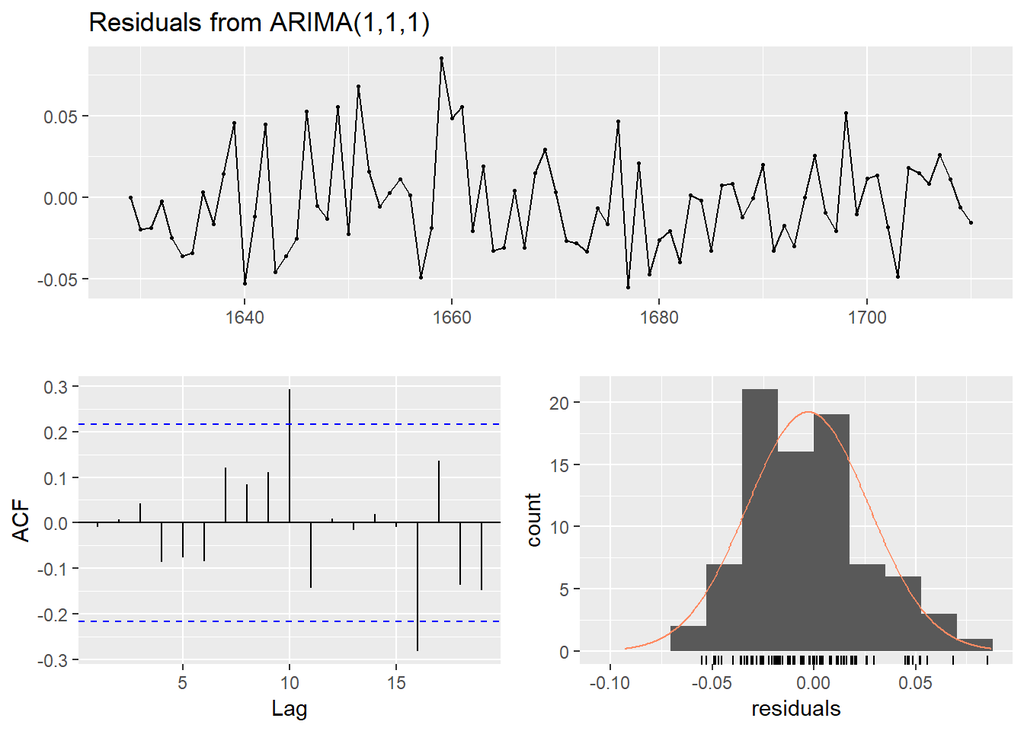

```
##
##  Ljung-Box test
##
## data:  Residuals from ARIMA(1,1,1)
## Q* = 13.337, df = 8, p-value = 0.1008
##
## Model df: 2.   Total lags used: 10
```

```r
#############
#  Modelo 1 #
#############

checkresiduals(model_1)
```

```r
LjungBoxTest(residuals(model_1), k = 2, lag.max = 20)
```

```
##   m    Qm     pvalue
##   1  0.01 0.92611002
##   2  0.01 0.91139925
##   3  0.17 0.68276539
##   4  0.82 0.66216496
##   5  1.35 0.71745835
##   6  1.99 0.73828536
##   7  3.32 0.65017878
##   8  3.98 0.67886254
##   9  5.16 0.64076272
##  10 13.34 0.10075806
##  11 15.32 0.08260244
##  12 15.32 0.12066369
##  13 15.35 0.16692082
##  14 15.39 0.22084407
##  15 15.40 0.28310047
##  16 23.69 0.04989871
##  17 25.63 0.04204503
##  18 27.65 0.03480954
##  19 30.06 0.02590249
##  20 30.07 0.03680262
```

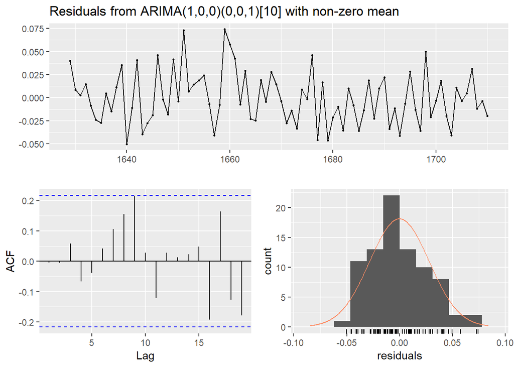

```
##
##  Ljung-Box test
##
## data:  Residuals from ARIMA(1,0,0)(0,0,1)[10] with non-zero mean
## Q* = 8.6327, df = 7, p-value = 0.2801
##
## Model df: 3.   Total lags used: 10
```

```r
#sarima(excess_ts, p = 1, d = 1, q = 1)

#############
#  Modelo 2 #
#############

checkresiduals(model_2)
```

```r
LjungBoxTest(residuals(model_2), k = 2, lag.max = 20)
```

```
##   m    Qm    pvalue
##   1  0.00 0.9674875
##   2  0.00 0.9545816
##   3  0.30 0.5815774
##   4  0.69 0.7096699
##   5  0.82 0.8442508
##   6  0.98 0.9121811
##   7  2.01 0.8481327
##   8  4.24 0.6442302
##   9  8.56 0.2861290
##  10  8.63 0.3742209
##  11 10.06 0.3459882
##  12 10.13 0.4290298
##  13 10.15 0.5172343
##  14 10.20 0.5985932
##  15 10.44 0.6577499
##  16 14.30 0.4275627
##  17 17.14 0.3104476
##  18 18.86 0.2759461
##  19 22.35 0.1715052
##  20 22.41 0.2142307
```

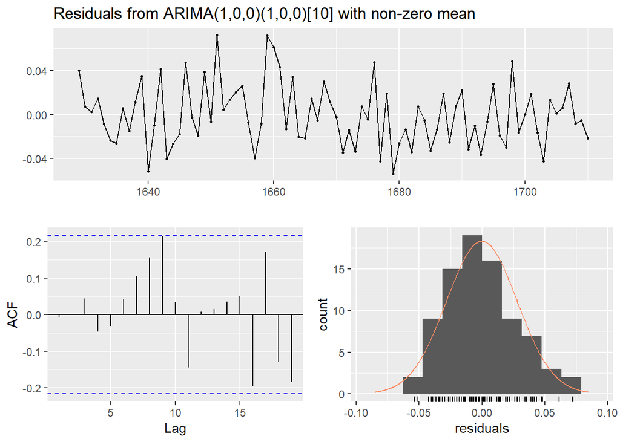

```
##
##  Ljung-Box test
##
## data:  Residuals from ARIMA(1,0,0)(1,0,0)[10] with non-zero mean
## Q* = 8.345, df = 7, p-value = 0.3032
##
## Model df: 3.   Total lags used: 10
```

```r
#sarima(excess_ts, p = 1, d = 0, q = 0, P = 0, D = 0, Q = 1, S = 10)

#############
#  Modelo 3 #
#############

checkresiduals(model_3)
```

```r
LjungBoxTest(residuals(model_3), k = 2, lag.max = 20)
```

```
##   m    Qm    pvalue
##   1  0.00 0.9583318
##   2  0.00 0.9553365
##   3  0.18 0.6719971
##   4  0.37 0.8313599
##   5  0.46 0.9285781
##   6  0.63 0.9600113
##   7  1.63 0.8975737
##   8  3.90 0.6901431
##   9  8.23 0.3126132
##  10  8.34 0.4005182
##  11 10.36 0.3222430
##  12 10.36 0.4091634
##  13 10.39 0.4960029
##  14 10.52 0.5708185
##  15 10.78 0.6290166
##  16 14.81 0.3914043
##  17 17.91 0.2675070
##  18 19.69 0.2343648
##  19 23.37 0.1374412
##  20 23.70 0.1651785
```

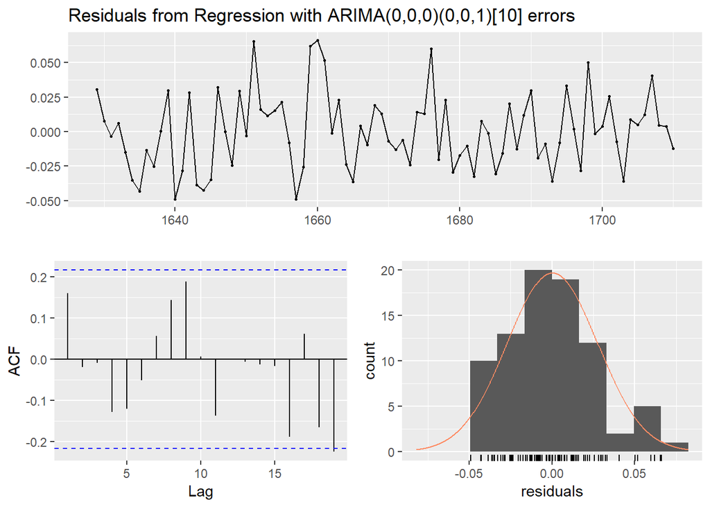

```
##
##  Ljung-Box test
##
## data:  Residuals from Regression with ARIMA(0,0,0)(0,0,1)[10] errors
## Q* = 10.787, df = 7, p-value = 0.1482
##
## Model df: 3.   Total lags used: 10
```

```r
#sarima(excess_ts, p = 1, d = 0, q = 0, P = 1, D = 0, Q = 0, S = 10)

#############
#  Modelo 4 #
#############

checkresiduals(model_4)
```

```r
LjungBoxTest(residuals(model_4), k = 1, lag.max = 20)
```

```
##   m    Qm    pvalue
##   1  2.20 0.1379312
##   2  2.23 0.1349922
##   3  2.24 0.3262675
##   4  3.68 0.2977682
##   5  4.99 0.2884494
##   6  5.23 0.3884858
##   7  5.52 0.4787801
##   8  7.45 0.3837810
##   9 10.78 0.2142605
##  10 10.79 0.2905934
##  11 12.61 0.2465522
##  12 12.61 0.3198632
##  13 12.61 0.3979718
##  14 12.63 0.4769589
##  15 12.65 0.5538915
##  16 16.37 0.3578806
##  17 16.77 0.4005631
##  18 19.73 0.2882971
##  19 25.25 0.1182396
##  20 25.31 0.1504763
```

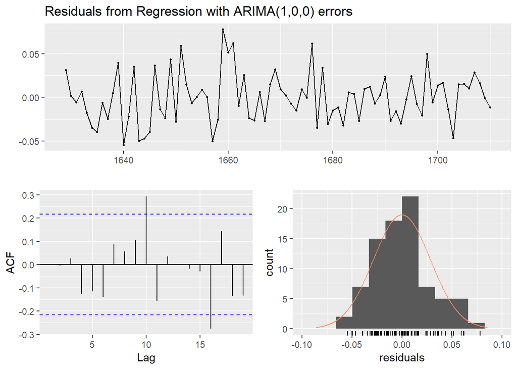

```
##
##  Ljung-Box test
##
## data:  Residuals from Regression with ARIMA(1,0,0) errors
## Q* = 14.72, df = 7, p-value = 0.03975
##
## Model df: 3.   Total lags used: 10
```

```r
#sarima(excess_ts, p = 0, d = 0, q = 0, P = 0, D = 0, Q = 1, S = 10, xreg = level)


#############
#  Modelo 6 #
#############

checkresiduals(model_6)
```

```r
LjungBoxTest(residuals(model_6), k = 1, lag.max = 20)
```

```
##   m    Qm     pvalue
##   1  0.00 0.99713258
##   2  0.00 0.96036600
##   3  0.07 0.96612792
##   4  1.51 0.67947886
##   5  2.70 0.60998895
##   6  4.47 0.48361437
##   7  5.20 0.51895133
##   8  5.49 0.59997164
##   9  6.51 0.58979614
##  10 14.72 0.09890580
##  11 17.09 0.07239050
##  12 17.21 0.10175761
##  13 17.21 0.14179063
##  14 17.24 0.18844158
##  15 17.34 0.23872998
##  16 25.31 0.04596230
##  17 27.53 0.03591335
##  18 29.50 0.03021450
##  19 31.47 0.02537517
##  20 31.71 0.03370585
```

```r
#sarima(excess_ts, p = 1, d = 0, q = 0, xreg = level)
```

## Comparación de modelos

```r
df <- data.frame(col_1_res = c(model_1$aic, model_2$aic, model_3$aic, model_4$aic, model_6$aic),
                 col_2_res = c(model_1$aicc, model_2$aicc, model_3$aicc, model_4$aicc, model_6$aicc),
                 col_3_res = c(model_1$bic, model_2$bic, model_3$bic, model_4$bic, model_6$bic))

colnames(df) <- c("AIC", "AICc", "BIC")
rownames(df) <- c("ARIMA(1,1,1)",
                  "ARIMA(1,0,0)(0,0,1)[10]",
                  "ARIMA(1,0,0)(1,0,0)[10]",
                  "ARIMA(0,0,0)(0,0,1)[10] with level shift",
                  "ARIMA(1,0,0) with level shift")

formattable(df)
```

|  | AIC | AICc | BIC |
| --- | --- | --- | --- |
| ARIMA(1,1,1) | -329.8844 | -329.5727 | -322.7010 |
| ARIMA(1,0,0)(0,0,1)[10] | -344.4575 | -343.9380 | -334.8306 |
| ARIMA(1,0,0)(1,0,0)[10] | -344.1906 | -343.6711 | -334.5637 |
| ARIMA(0,0,0)(0,0,1)[10] with level shift | -348.8963 | -348.3768 | -339.2694 |
| ARIMA(1,0,0) with level shift | -343.3529 | -342.8334 | -333.7260 |

El modelo que proporciona las mejores métricas AIC, AICc y BIC al mismo tiempo#es el modelo n. ° 4, ARIMA (0,0,0) (0,0,1) con cambio de nivel.

## Pronóstico

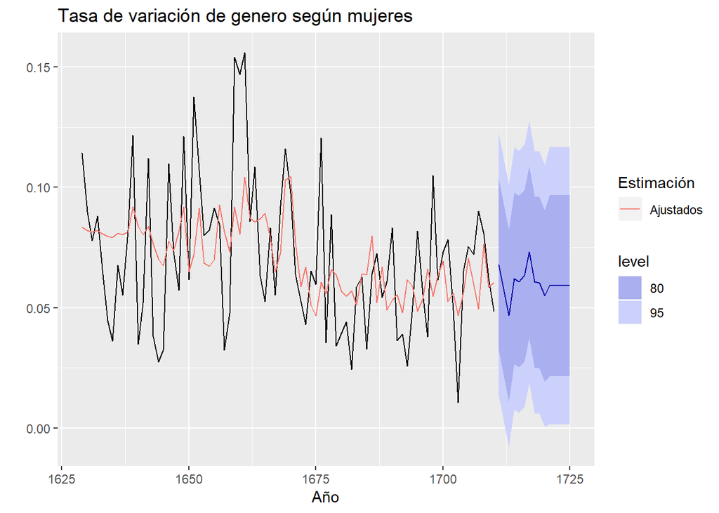

```r
 horizonte<- 15
# plot(forecast(model_4, h = horizonte, xreg = rep(1, horizonte)))

model_4 %>% forecast(h=24, xreg = rep(1, horizonte) ) %>%
  autoplot() +
  autolayer(fitted(model_4), series="Ajustados") +
  ylab("") + xlab("Año") +
  ggtitle("Tasa de variación de genero según mujeres") +
  guides(colour=guide_legend(title="Estimación"))
```

# Intervención m=c , c>1

## Descripción de los datos

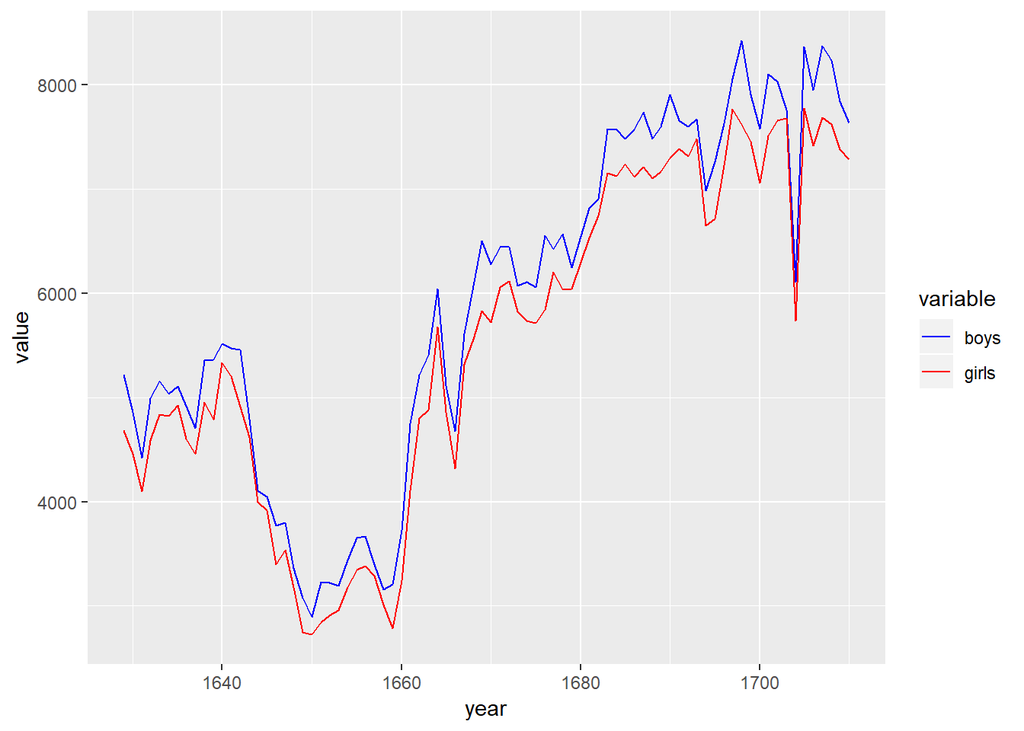

```r
ggplot(data = abhutondot_rs, aes(x = year)) + geom_line(aes(y = value, colour = variable)) +
  scale_colour_manual(values = c("blue", "red"))
```

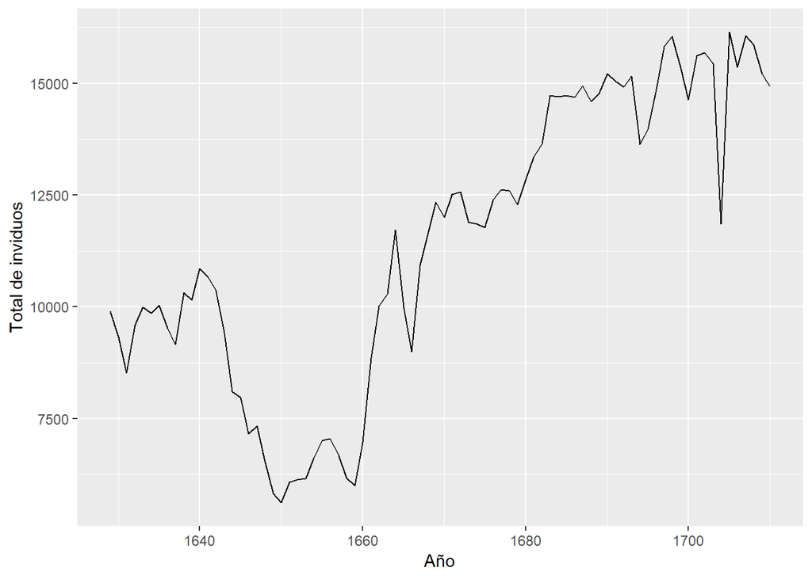

```r
abhutondot.ts <- ts(abhutondot$boys + abhutondot$girls, frequency = 1 , start = abhutondot$year[1])

autoplot(abhutondot.ts) +  ylab("Total de inviduos") + xlab("Año")
```

```r
summary(lm(abhutondot.ts ~ 1))
```

```
##
## Call:
## lm(formula = abhutondot.ts ~ 1)
##
## Residuals:
##     Min      1Q  Median      3Q     Max
## -5829.7 -2243.0   371.3  3281.3  4703.3
##
## Coefficients:
##             Estimate Std. Error t value Pr(>|t|)
## (Intercept)    11442        358   31.96   <2e-16 ***
## ---
## Signif. codes:  0 '***' 0.001 '**' 0.01 '*' 0.05 '.' 0.1 ' ' 1
##
## Residual standard error: 3242 on 81 degrees of freedom
```

## Cambio estructurales

```r
(break_point <- breakpoints(abhutondot.ts ~ 1))
```

```
##
##   Optimal 4-segment partition:
##
## Call:
## breakpoints.formula(formula = abhutondot.ts ~ 1)
##
## Breakpoints at observation number:
## 15 33 52
##
## Corresponding to breakdates:
## 1643 1661 1680
```

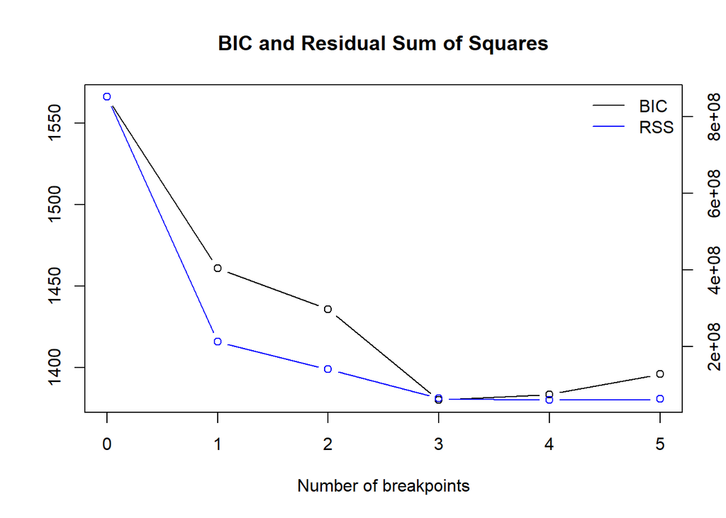

```r
plot(break_point)
```

```r
summary(break_point)
```

```
##
##   Optimal (m+1)-segment partition:
##
## Call:
## breakpoints.formula(formula = abhutondot.ts ~ 1)
##
## Breakpoints at observation number:
##
## m = 1         39
## m = 2      33    52
## m = 3   15 33    52
## m = 4   15 33    52 68
## m = 5   15 32 44 56 68
##
## Corresponding to breakdates:
##
## m = 1             1667
## m = 2        1661      1680
## m = 3   1643 1661      1680
## m = 4   1643 1661      1680 1696
## m = 5   1643 1660 1672 1684 1696
##
## Fit:
##
## m   0         1         2         3         4         5
## RSS 851165494 211346686 139782582  63564154  59593922  62188019
## BIC      1566      1461      1436      1380      1383      1396
```

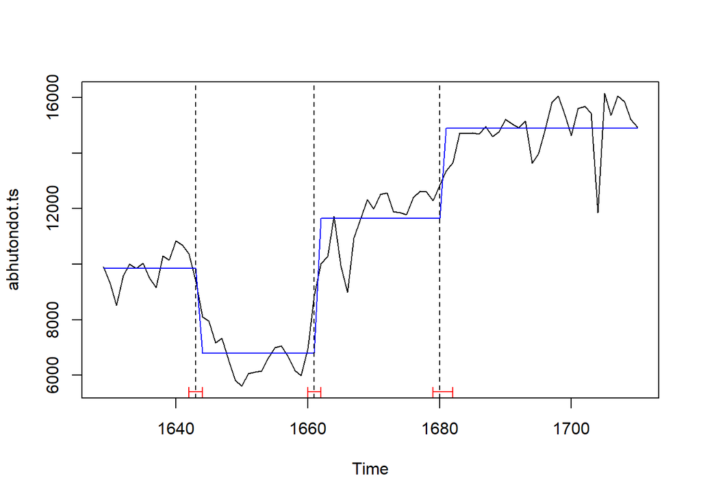

```r
#El valor mínimo de BIC se alcanza con m = 3. Tracemos la serie temporal original
#contra sus rupturas estructurales y sus intervalos de confianza.

plot(abhutondot.ts)
fitted.ts <- fitted(break_point, breaks = 3)
lines(fitted.ts, col = 4)
lines(confint(break_point, breaks = 3))
```

```r
#Los niveles ajustados y las fechas de los puntos de interrupción son los siguientes.

unique(as.integer(fitted.ts))
```

```
## [1]  9843  6791 11645 14902
```

```r
breakdates(break_point, breaks = 3)
```

```
## [1] 1643 1661 1680
```

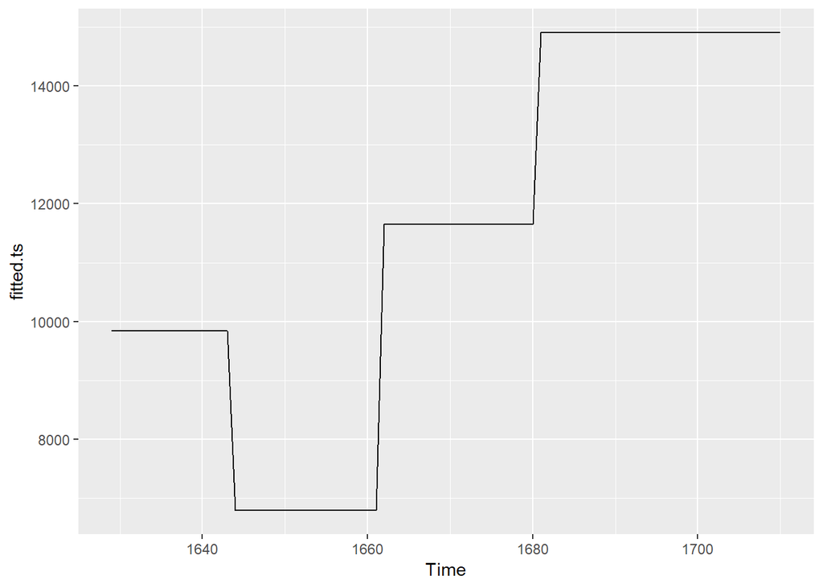

```r
fitted.ts <- fitted(break_point, breaks = 3)
autoplot(fitted.ts)
```

```r
fitted.ts
```

```
## Time Series:
## Start = 1629
## End = 1710
## Frequency = 1
##  [1]  9843.533  9843.533  9843.533  9843.533  9843.533  9843.533  9843.533
##  [8]  9843.533  9843.533  9843.533  9843.533  9843.533  9843.533  9843.533
## [15]  9843.533  6791.389  6791.389  6791.389  6791.389  6791.389  6791.389
## [22]  6791.389  6791.389  6791.389  6791.389  6791.389  6791.389  6791.389
## [29]  6791.389  6791.389  6791.389  6791.389  6791.389 11645.263 11645.263
## [36] 11645.263 11645.263 11645.263 11645.263 11645.263 11645.263 11645.263
## [43] 11645.263 11645.263 11645.263 11645.263 11645.263 11645.263 11645.263
## [50] 11645.263 11645.263 11645.263 14902.167 14902.167 14902.167 14902.167
## [57] 14902.167 14902.167 14902.167 14902.167 14902.167 14902.167 14902.167
## [64] 14902.167 14902.167 14902.167 14902.167 14902.167 14902.167 14902.167
## [71] 14902.167 14902.167 14902.167 14902.167 14902.167 14902.167 14902.167
## [78] 14902.167 14902.167 14902.167 14902.167 14902.167
```

## Estimación del modelo ARIMA

Realmente no lo hice bien, creo que lo correcto es como estan lo hizo

```r
#x1 <-  x1<-rep(1,length(abhutondot.ts))
#x2<-x1
#x3<-x1
#x4<-x1

#x1[1:33]<-0
#x2[1:15]<-0
#x3[1:52]<-0
#x4[1:82]<-0

#x<- cbind(x1,x2,x3,x4)

#modelo3.2<-Arima(datos.aprendi, order=c(0,1,1), include.drift = T, xreg = x)
#coeftest(modelo3.2)
#checkresiduals(modelo3.2)
#g10<-autoplot(datos.aprendi, series="Observado")+
  #autolayer(fitted(modelo3.2), series="Ajustados")+ylab("Cantidad")+
  #xlab("Tiempo")+
  #theme_bw() +mithema2+theme(legend.position="bottom")+
  #ggtitle("Valores ajustados y observados por año")
#g10
#source("funciones series.R")
#salida<-vis.resi(modelo3.1, retrasos = 60)

#x1n<-rep(1,54)
#x2n<-rep(1,54)
#x3n<-rep(1,54)
#x4n<-rep(1,54)

#newdata <- cbind(x1=x1n,x2=x2n, x3=x3n,x4=x4n) %>% as.data.frame()
#f.modelo3.2<-forecast(modelo3.2, h=54, xreg=newdata)
```

Yo lo hice de esta forma para poder obtener un resultado

```r
length(abhutondot.ts)
```

```
## [1] 82
```

```r
level1 <- c(rep(1, 15), rep(0, 18), rep(2,19), rep(3,30))

abhutondot_xreg <- Arima(abhutondot.ts,
                        order = c(0,1,1),
                        xreg = level1,
                        include.mean = TRUE)

summary(abhutondot_xreg)
```

```
## Series: abhutondot.ts
## Regression with ARIMA(0,1,1) errors
##
## Coefficients:
##           ma1    level1
##       -0.5359  1475.484
## s.e.   0.1468   396.847
##
## sigma^2 estimated as 745485:  log likelihood=-661.72
## AIC=1329.45   AICc=1329.76   BIC=1336.63
##
## Training set error measures:
##                    ME     RMSE      MAE         MPE     MAPE     MASE
## Training set 66.05865 847.4737 624.7251 -0.06805648 5.976659 1.006479
##                    ACF1
## Training set 0.07496522
```

El análisis de los residuos es el siguiente

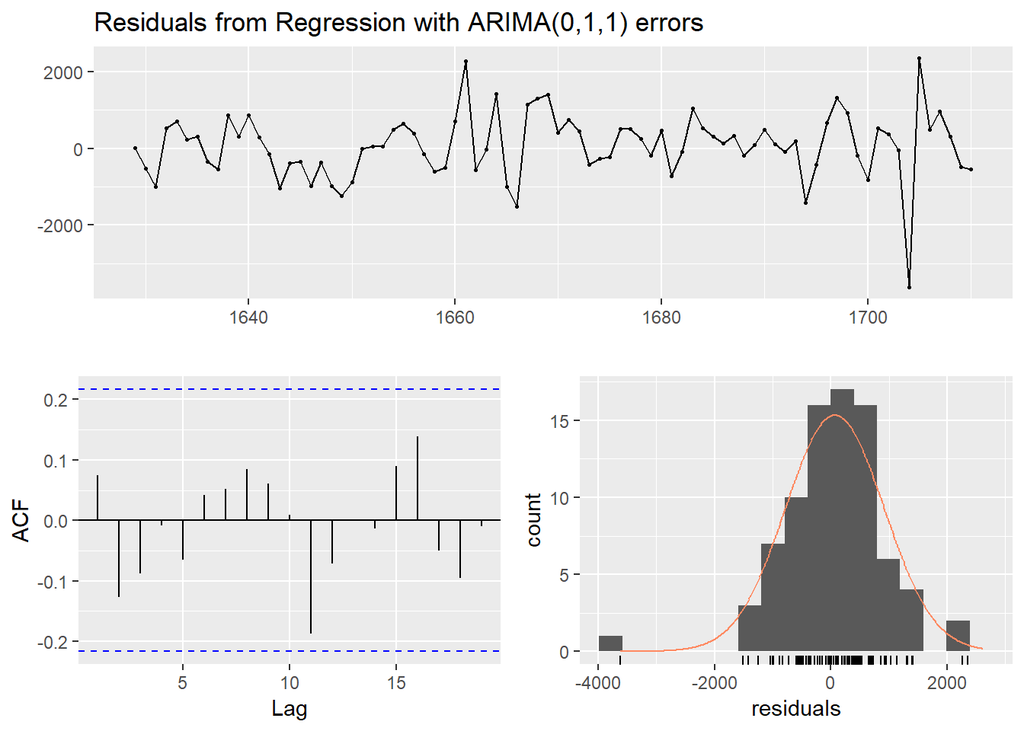

```
##
##  Ljung-Box test
##
## data:  Residuals from Regression with ARIMA(0,1,1) errors
## Q* = 4.3433, df = 8, p-value = 0.8249
##
## Model df: 2.   Total lags used: 10
```

```r
checkresiduals(abhutondot_xreg)
```

```r
LjungBoxTest(residuals(abhutondot_xreg), k=1, lag.max=20)
```

```
##   m    Qm    pvalue
##   1  0.48 0.4893797
##   2  1.85 0.1738799
##   3  2.52 0.2835775
##   4  2.53 0.4703580
##   5  2.90 0.5745934
##   6  3.06 0.6909469
##   7  3.31 0.7687728
##   8  3.99 0.7811911
##   9  4.33 0.8257516
##  10  4.34 0.8874018
##  11  7.72 0.6561040
##  12  8.22 0.6935201
##  13  8.22 0.7677423
##  14  8.24 0.8277245
##  15  9.06 0.8271438
##  16 11.06 0.7480516
##  17 11.33 0.7884719
##  18 12.31 0.7808279
##  19 12.32 0.8301545
##  20 12.57 0.8599918
```

## Pronósticos

Señoras y señoras, acá los pronósticos…

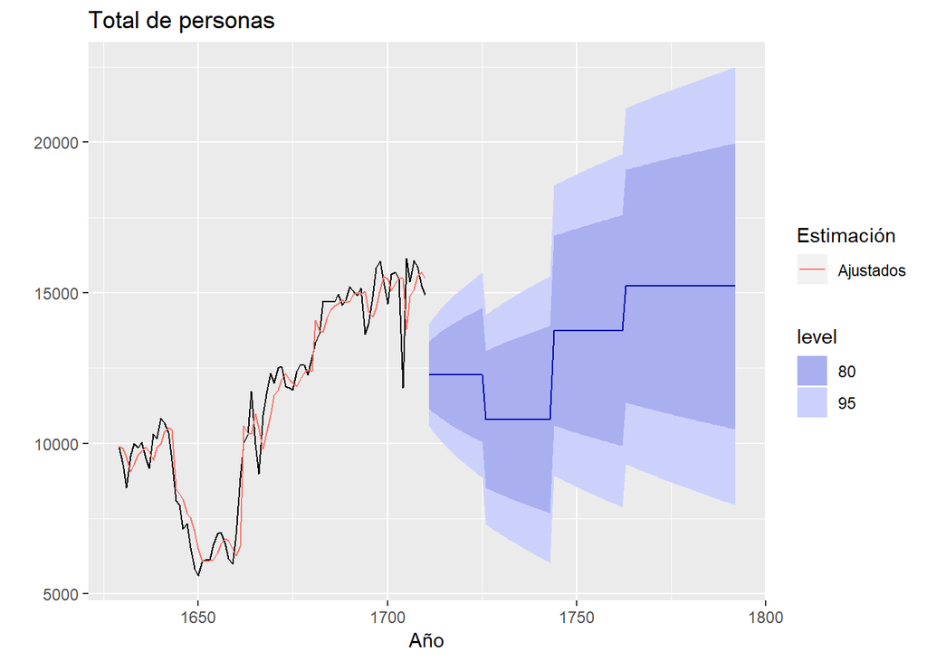

```r
abhutondot_xreg <- Arima(abhutondot.ts,
                         order = c(0,1,1),
                         xreg = level1,
                         include.mean = TRUE)

horizonte <- 24

abhutondot_xreg %>% forecast(h=24, xreg = level1) %>%
  autoplot() +
  autolayer(fitted(abhutondot_xreg), series="Ajustados") +
  ylab("") + xlab("Año") +
  ggtitle("Total de personas") +
  guides(colour=guide_legend(title="Estimación"))
```

# Valores faltantes

## Aplicación

Veamos la serie Gold, la cual posee valores faltantes

[figure not shown]

```r
autoplot(gold) + ylab("Taza de varianción de las mujeres") + xlab("Año")
```

Apliquemos la imputación de los valores faltantes

```r
gold2 <- na.interp(gold)

datos_gold <- data.frame(gold,gold2)

formattable(datos_gold)
```

[output not shown]

[output cut: 1078 more lines]

Veamos la serie con los valores imputados

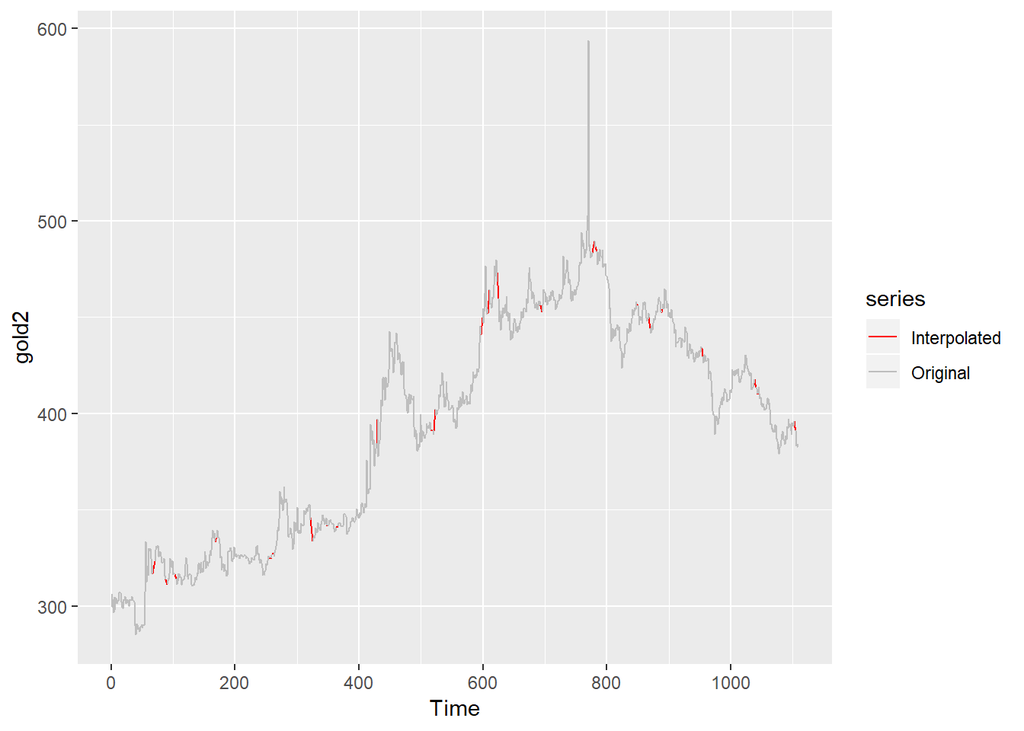

```r
autoplot(gold2, series="Interpolated") +
  autolayer(gold, series="Original") +
  scale_colour_manual(
    values=c(`Interpolated`="red",`Original`="gray"))
```

# Valoes extremos u outliers

## Aplicación

En la serie de gold vemos un valor extremo u outlier

[figure not shown]

```r
autoplot(gold) + ylab("Taza de varianción de las mujeres") + xlab("Año")
```

Verifiquemos si el pico se detecta como un outlier

```r
tsoutliers(gold)
```

```
## $index
## [1] 770
##
## $replacements
## [1] 494.9
```

```r
gold[768:772]
```

```
## [1] 495.00 502.75 593.70 487.05 487.75
```

Apliquemos la función tsclean() como una opción para lidiar tanto con valores faltantes como con valores extremos - outliers

Nótse que el ets() funciona únicamente con series donde no poseemos valores faltantes…

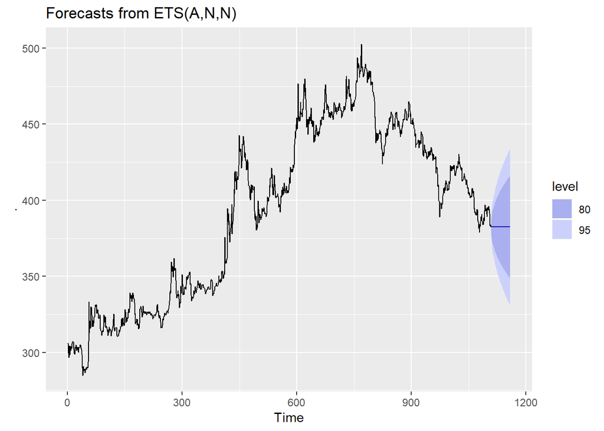

```r
gold %>%
  tsclean() %>%
  ets(model ="ZZZ", damped = NULL) %>%
  forecast(h=50) %>%
  autoplot()
```